# StackExchange Post Exploratory Analysis by Nathan Margaglio

> The data we will be exploring comes from the StackExchange, a network of question-and-answer websites on topics in varied fields. Specifically, we will be examining data related to posts users have made to StackOverflow, a subsite of StackExchange dedicated to programming and development.

> StackOverflow is arguably the most popular forum for developer Q&A. The decision to examine the data from the site comes not only from the popularity of the site (so that we have much data to examine), but also from the idea that this data will be a good representation of the programming community as a whole.

> Recently, StackExchange offered Data Explorer, an open source tool for running arbitrary queries against public data from the Stack Exchange network. This allows us to gather data quickly and easily from the site via SQL queries, which is where the data we will be using for this analysis comes from.

> Specifically, we’re going to be looking at posts tagged with R, Pandas (a data analysis library for Python), and Matlab from the year 2016. The idea is to examine posts related to data analysis while considering the differences in programming languages. We also limit our selection to posts with answers (otherwise we will have too much data with too much noise). The SQL command used to run the query is:

> which can be run from the Data Explorer Site:

> http://data.stackexchange.com/stackoverflow/queries

> We hope to ultimately be able to find patterns in the StackExchange community’s posting habits as well as the differences in the posting habits of the sub-communities of those users who are involved in data analysis using R, Python, and Matlab.

# Univariate Plots Section

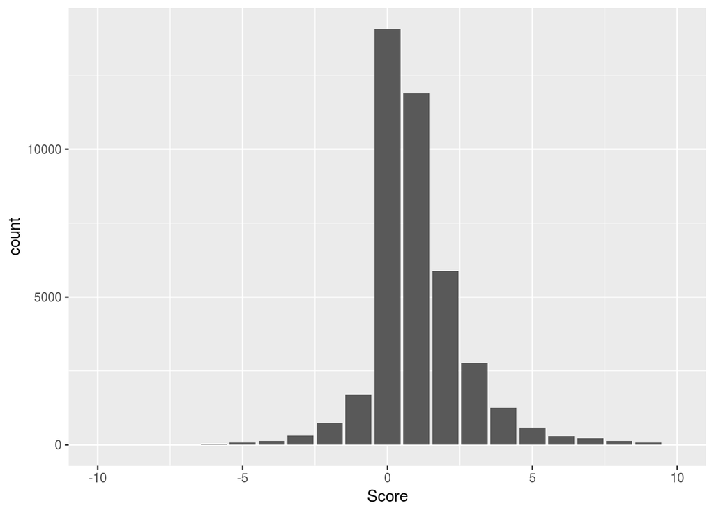

> Here we plot the count of the score for each post. We set our x limits to be -10 and 10, and we notice a very clear normal distribution centered at 0.

```
##    Min. 1st Qu.  Median    Mean 3rd Qu.    Max.
##  -16.00    0.00    1.00    1.07    2.00   71.00
```

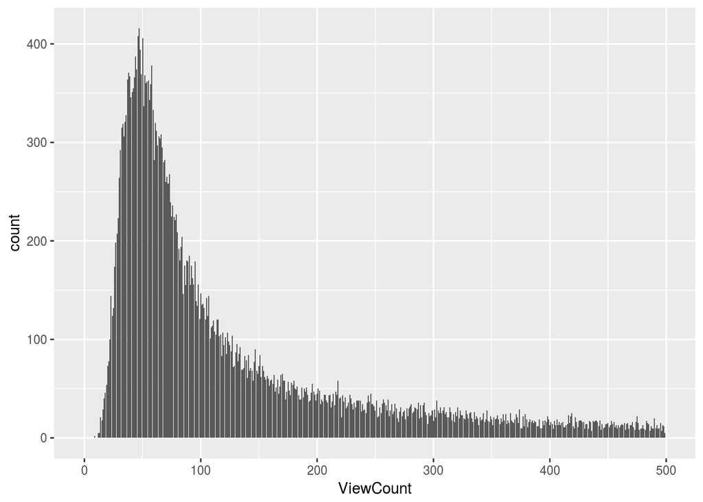

```
##    Min. 1st Qu.  Median    Mean 3rd Qu.    Max.
##     9.0    53.0    93.0   318.7   245.0 79147.0
```

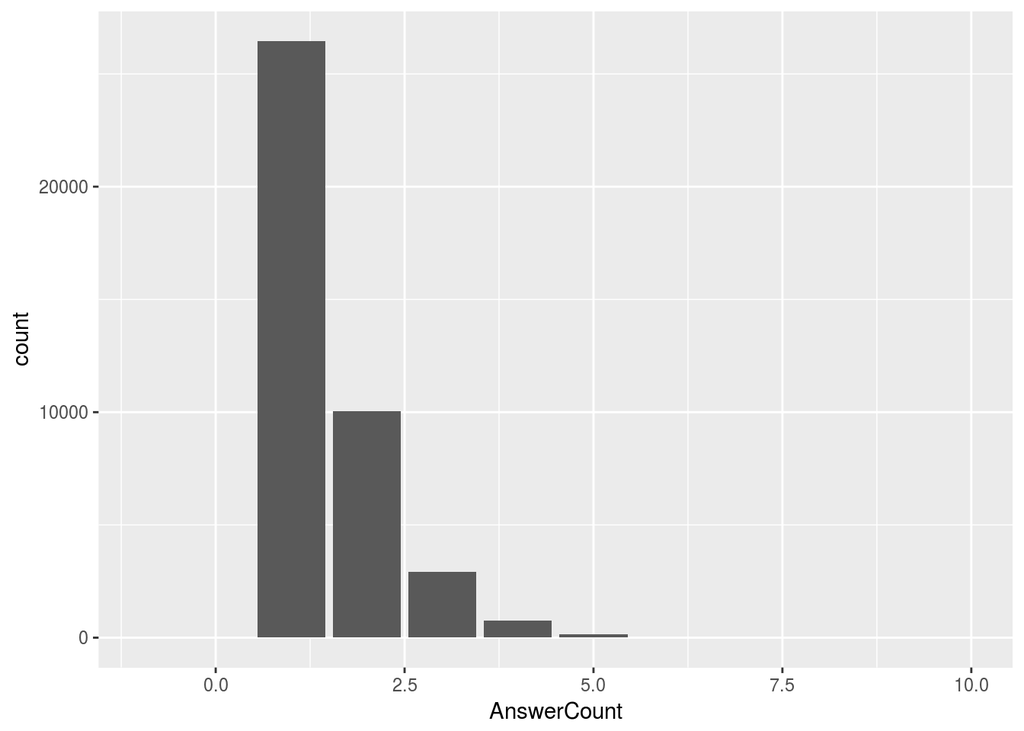

```
##    Min. 1st Qu.  Median    Mean 3rd Qu.    Max.
##    1.00    1.00    1.00    1.47    2.00    8.00
```

> Our dataset not only has a number of quanititative variables like we’ve seen above, but also temporal variables. Notably, the datetime of the posts creation and the closing is included and can be examined in a number of ways.

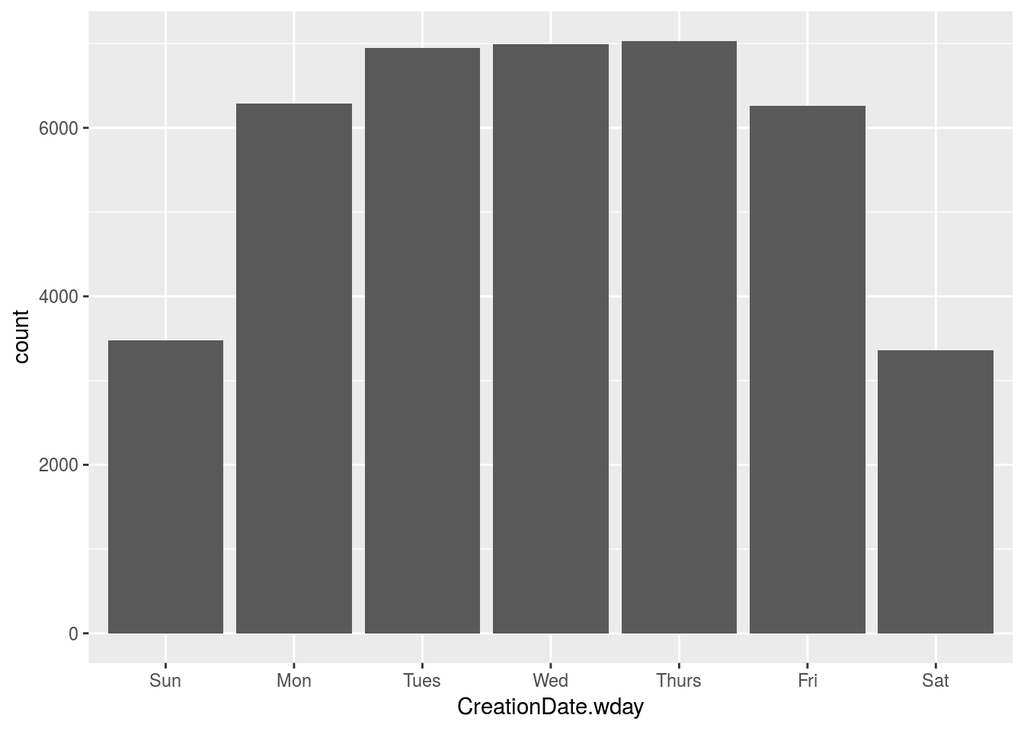

> Here we see when posts are created during the week. There is a clear relationship between the number of posts being created and whether or not it’s the weekend.

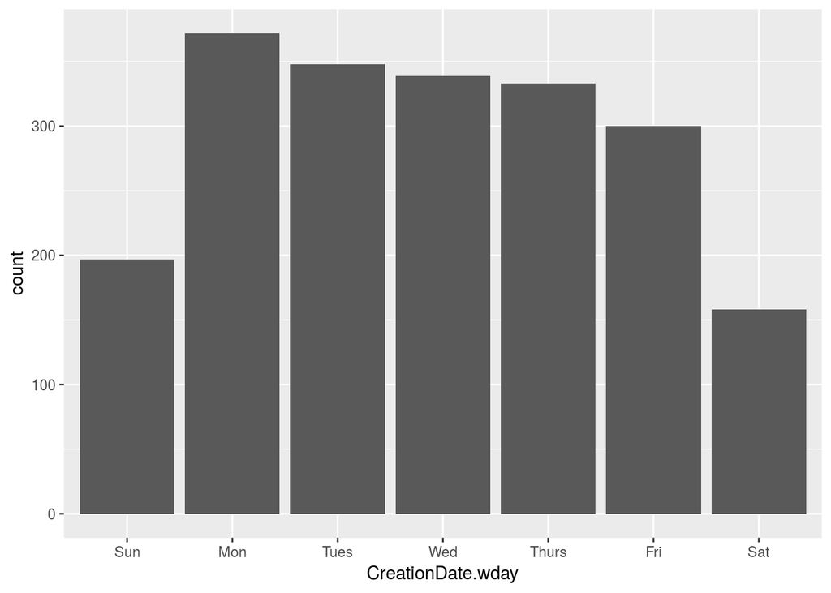

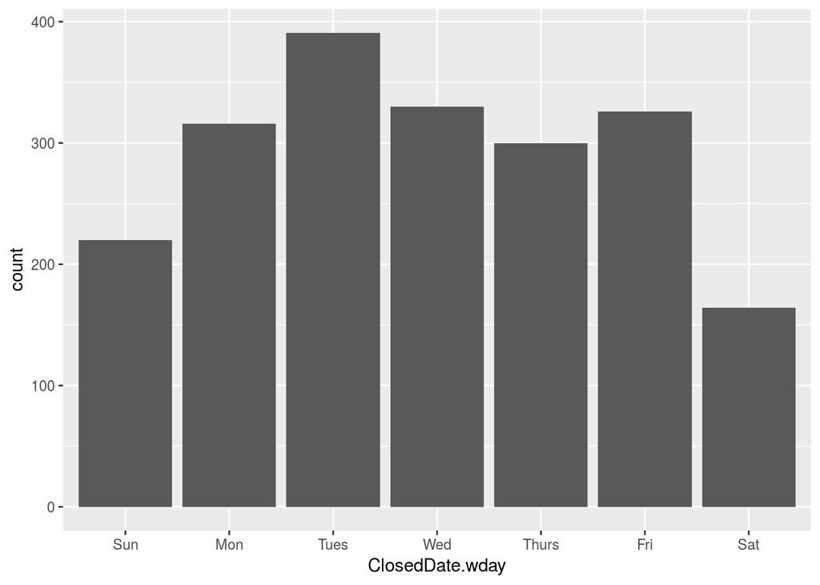

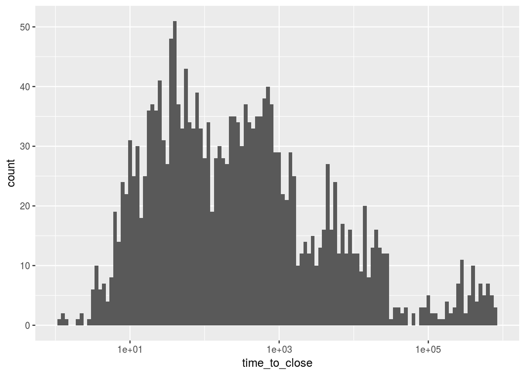

> Here, we’ve taken the difference (in minutes) of the Creation datetime and the Closed datetime. Most closed posts are closed within the first two hours.

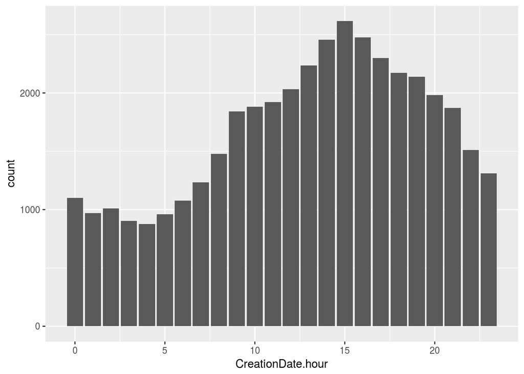

> Now we plot the hour of the day in which the posts were created. There is a clear trend here, with 4 in the morning being the least active time for the site and 3 in the afternoon being the most active.

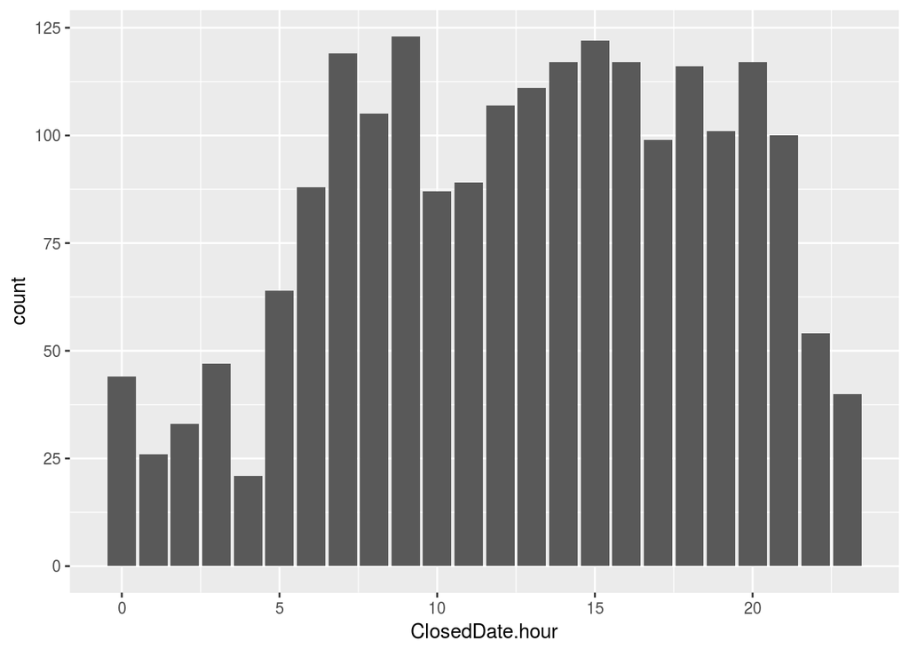

> Surprisingly, the hour of the day in which posts are closed is less clear. Unlike the hour of creation, busy activity is almost constant after 6 in the morning until about 9 at night, where it drops off for the rest of the night/morning.

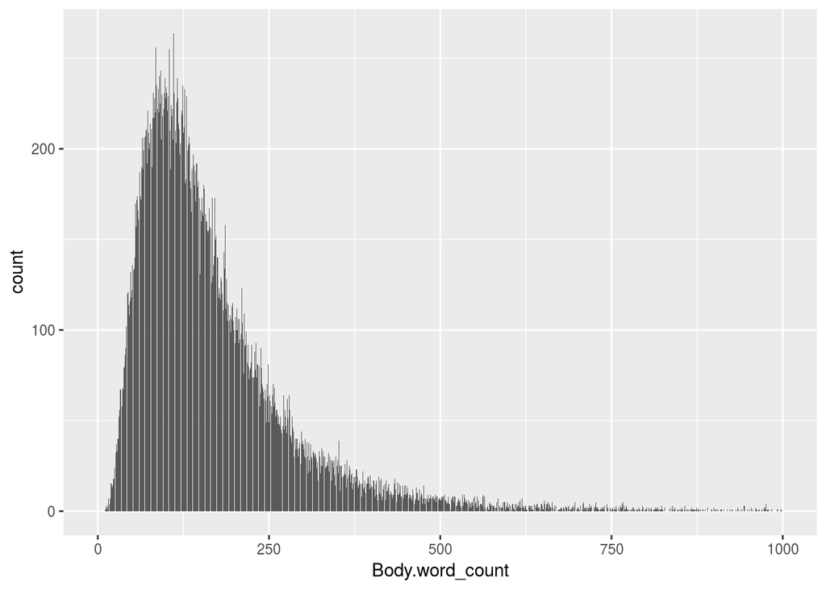

```
##    Min. 1st Qu.  Median    Mean 3rd Qu.    Max.
##    11.0    91.0   138.0   176.5   210.0  4321.0
```

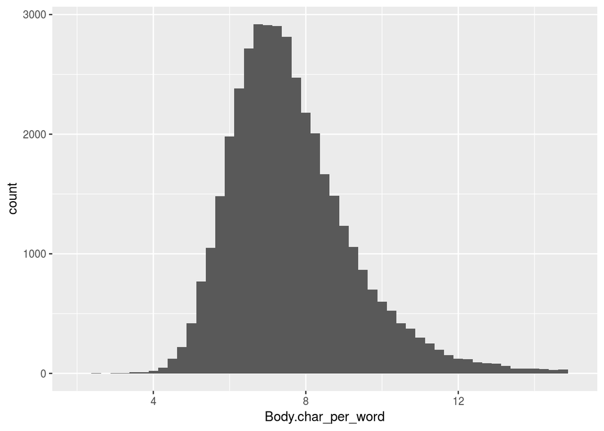

```
##    Min. 1st Qu.  Median    Mean 3rd Qu.    Max.
##   2.587   6.523   7.395   7.727   8.493 167.122
```

> Most posts contain about 150 words, with a median word count of 138 and a mean word count of 176.5. When looking at the amount of characters per word in the post body, we have an average 7.727 characters per word (with a median of 7.395 characters per word).

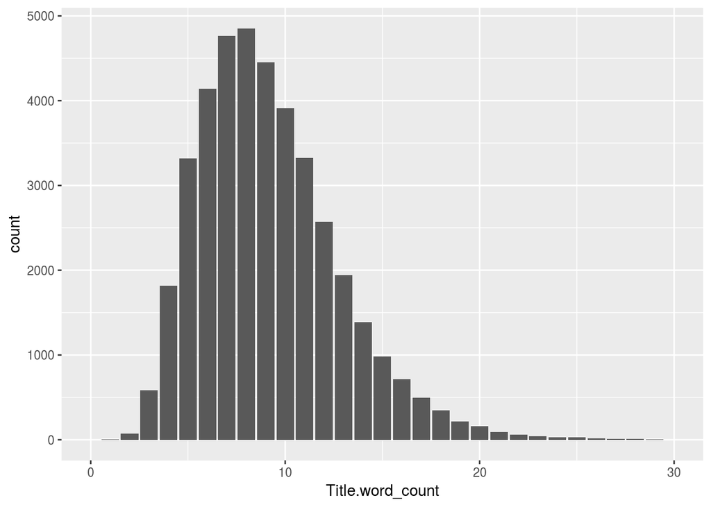

```
##    Min. 1st Qu.  Median    Mean 3rd Qu.    Max.
##   1.000   7.000   9.000   9.148  11.000  31.000
```

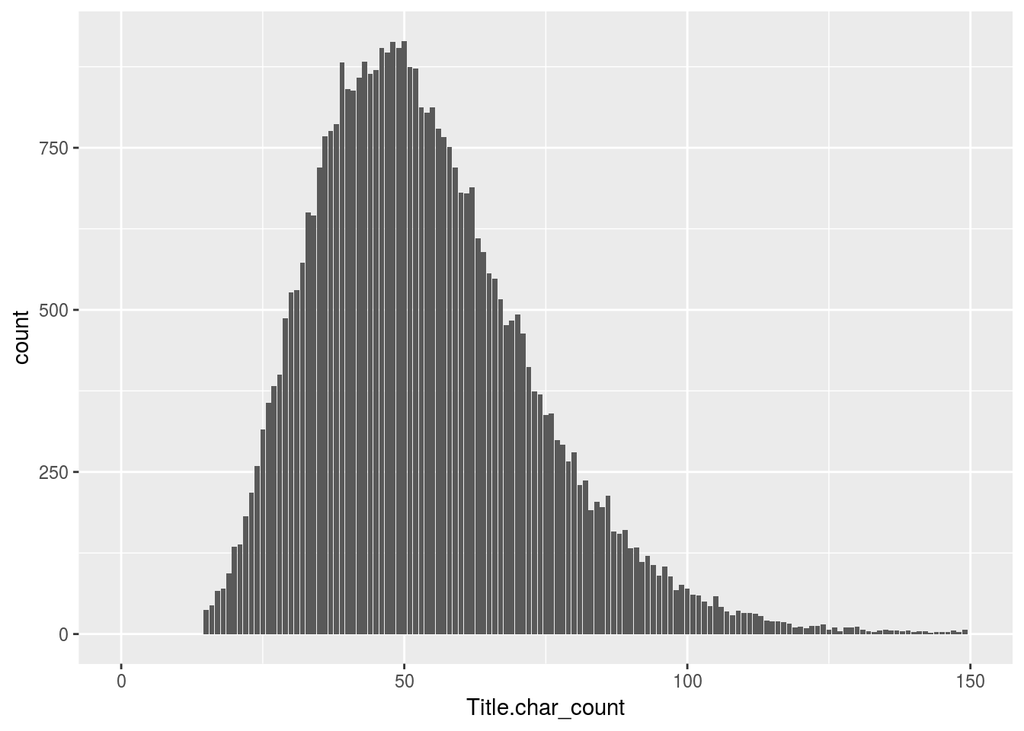

```
##    Min. 1st Qu.  Median    Mean 3rd Qu.    Max.
##   15.00   40.00   51.00   53.58   65.00  150.00
```

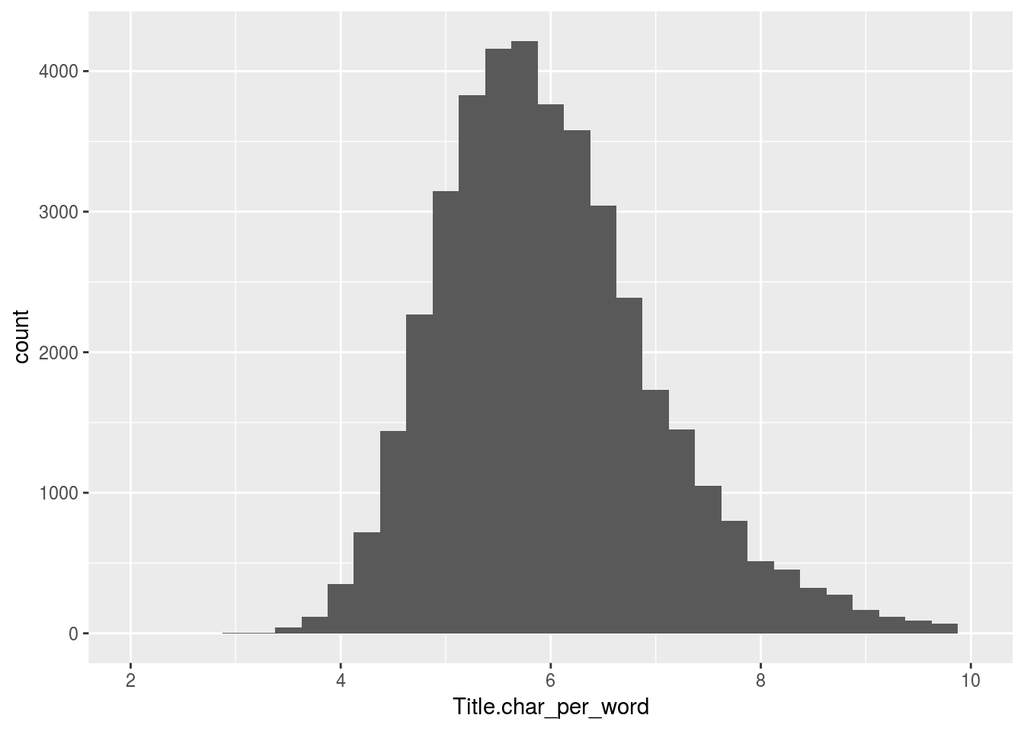

```
##    Min. 1st Qu.  Median    Mean 3rd Qu.    Max.
##   2.767   5.267   5.875   6.024   6.600  39.000
```

> Most post’s title contain about 9 words, with a median word count of 9 and a mean word count of 9.148. The median amount of characters used is 51, and the average amount of characters used it 53.58. This leads to an average 6.024 characters per word in the title (or a median of 5.875 characters per word).

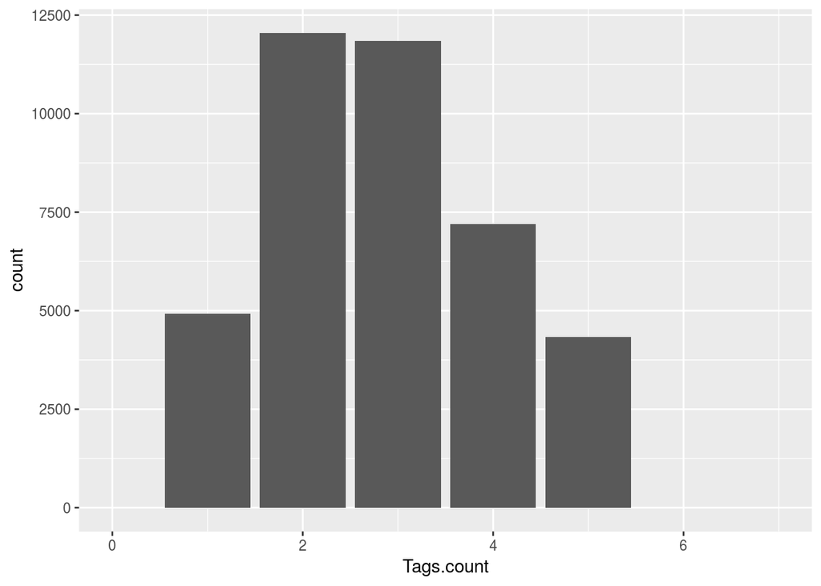

```
##    Min. 1st Qu.  Median    Mean 3rd Qu.    Max.
##    1.00    2.00    3.00    2.85    4.00    5.00
```

> Posts must contain at least one tag, but users can select multiple tags based on the content of their post. Most posts use about 3 tags, with the median being 3 and the mean being 2.85.

# Univariate Analysis

### What is the structure of your dataset?

There are 40,360 posts in the dataset with 22 original variables. Some of these variables, such as Id, AcceptedAnswerId, and OwnerUserId, are used for reference and can’t be used directly in analysis. These leaves us with the following features per observation that we can directly use:

- PostTypeId
- CreationDate
- DeletionDate
- Score
- ViewCount
- Body
- LastEditDate
- LastActivityDate
- Title
- Tags
- AnswerCount
- CommentCount
- FavoriteCount
- ClosedDate
- CommunityOwnedDate

Most of these variables aren’t present for many of the observations due to the nature of the site (for example, many posts don’t get edited, so their LastEditDate is null). So we have to be conscientious of this fact when exploring the dataset as a whole.

### What is/are the main feature(s) of interest in your dataset?

On StackExchange, a posts “value” can be roughly thought of as its contribution to the community, usually in the form of a question people think is worth answering and, of course, the answers given. This “value” is typically in corresponence with the post’s Score. A post starts with a score of 0, and each user is allowed to vote a score either up or down once, with a higher score reflecting a better post. This makes the score a key variable in our analysis.

### What other features in the dataset do you think will help support your investigation into your feature(s) of interest?

Another main feature is the various dates associated with a post, specifically the Creation Date and the Closed Date. Every post has a a creation date (which is the datetime in which the post was orginally submitted), but if a post is closed (e.g., it is marked as answered), then it will also have a closed date associate with it.

Each post is comprised of a title and body, which is comes in the form of text. These features are clearly important since they comprise the information for which a post is rated on. Posts also contain at least one tag, which is a broad subject in which the post is related.

### Did you create any new variables from existing variables in the dataset?

Yes, since the title and body variables are just text (with the body allowing for HTML markup), I had to abstract and investigate features of these variables, including the counts of words and characters for each.

Another important variable created for this analysis is the “MainTag” factor. This was created by parsing the Tags variable for one of three tags a post in this set has: “pandas”, “r”, and “matlab”. This helps us understand the subject of as post.

# Bivariate Plots Section

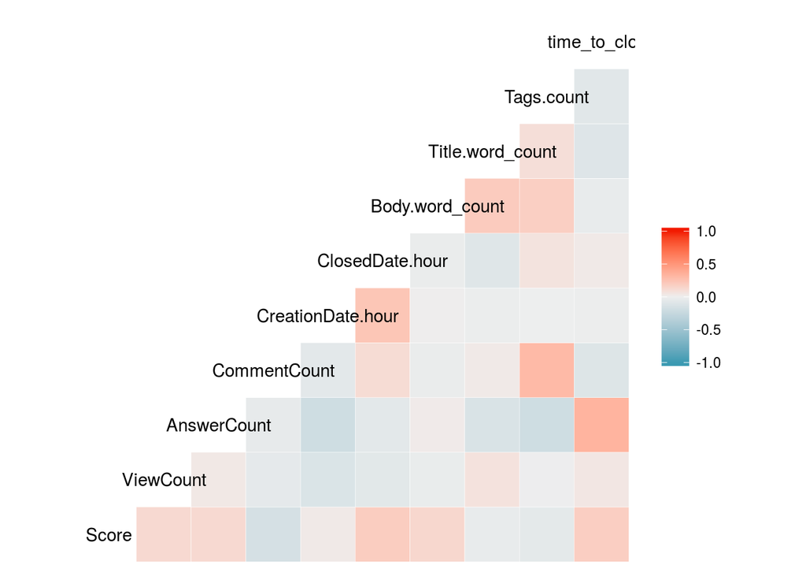

> To begin the bivariate exploration, I use the ‘ggcorr’ function to produce this heatmap matrix using a random sample of data. Here, I’m interested in seeing any patterns that emerge from comparing these combinations of variables in different ways. The result leads to some interesting correlations that I will explore in this section.

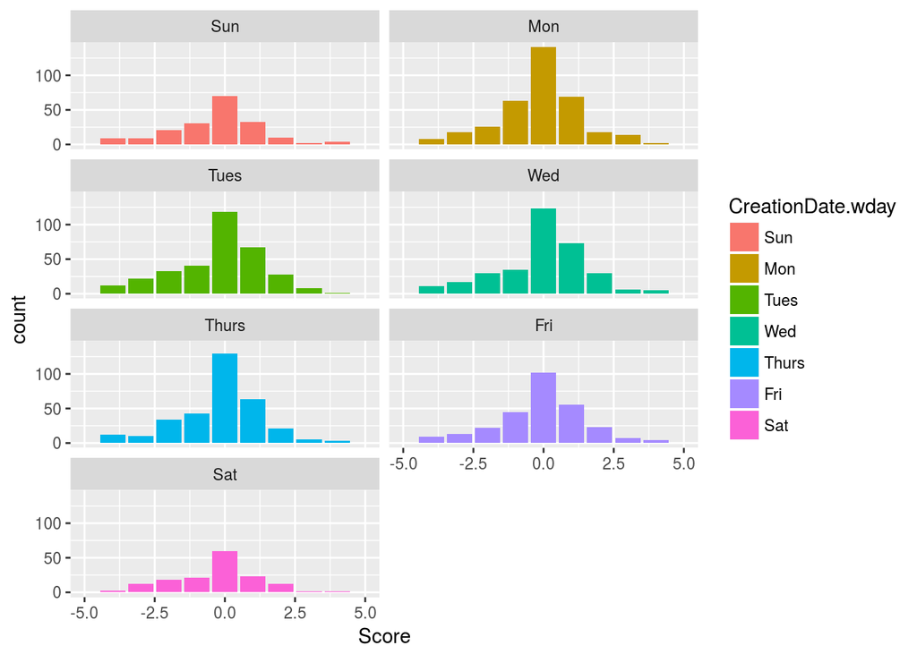

> Plotting a bar chart of the post’s score for everyday of the week during which it was created leads to the above array of plots. We can notice that, although the distribution of scores are similar per day, there are significant differnces. For example, Tuesday and Wednesday seem to be more negatively skewed, while Friday and Saturday are more uniform.

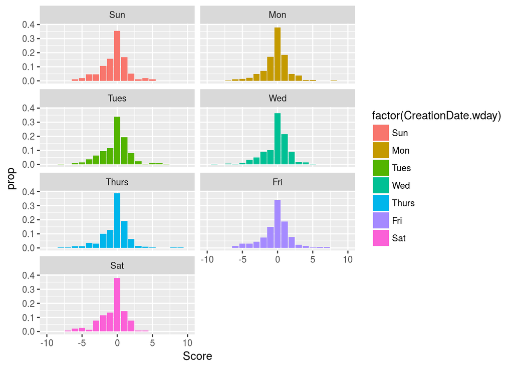

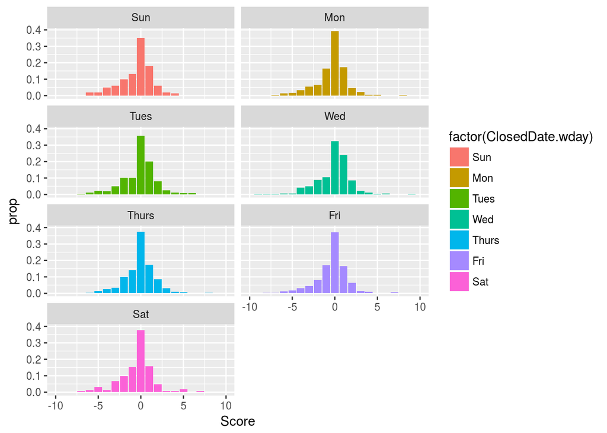

> Here, we plot the post’s score for every day of the week in which the post was closed (instead of open, like above).

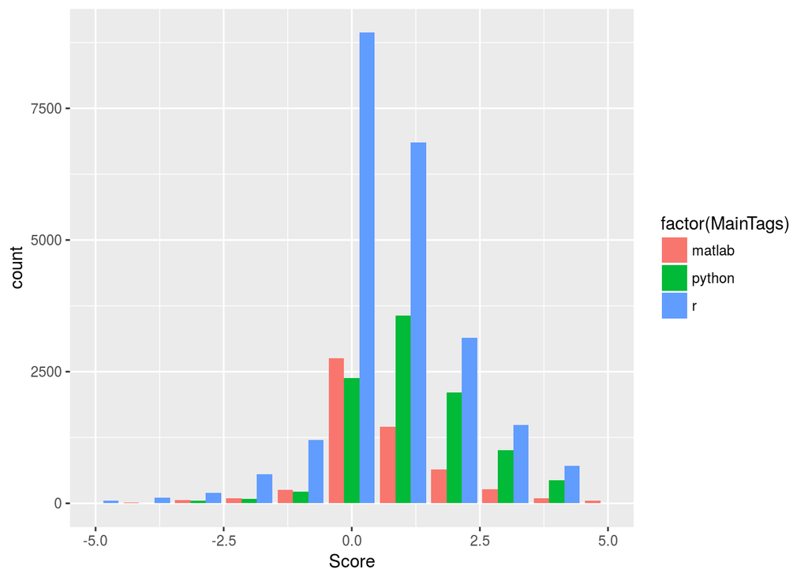

> Here we plot the score factored by our main tags. We see that there are more posts with ‘r’ as the main tag versus the other two, and ‘matlab’ having the least amount of posts.

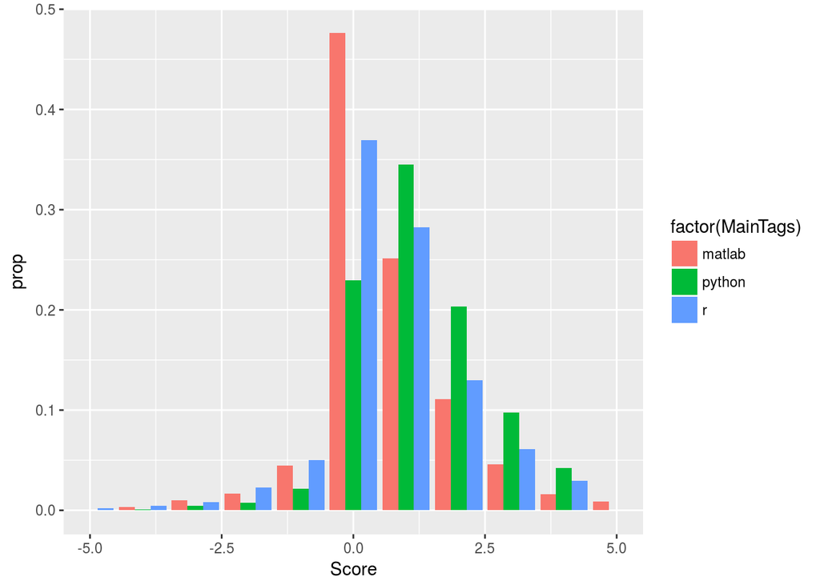

> This plot is similar to the above plot, except instead of plotting on raw counts of posts for each score, we plot the proportion of count of each score relative to the total amount of posts for each main tag. This plot is much more illuminating of the differences of these tags, with posts with ‘pandas’ as it’s main tag having ‘1’ being the leading score while ‘r’ and ‘matlab’ have ‘0’ as the leading score.

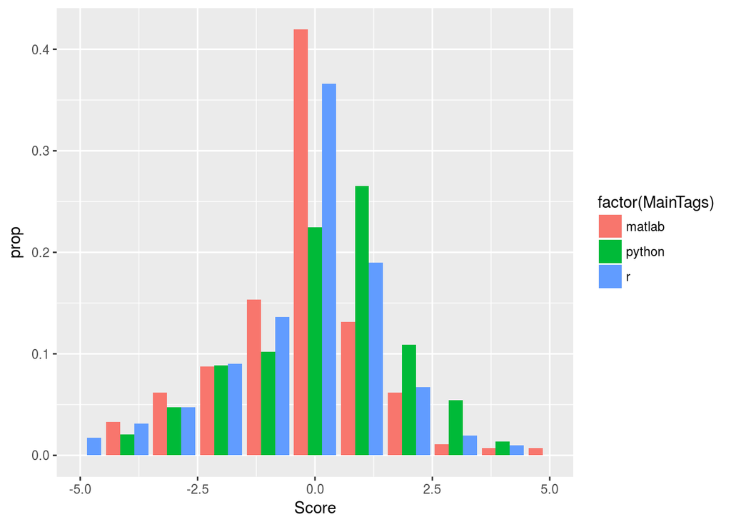

> This plot is similar to the above one, except we only consider posts that are closed. Notice the higher proportion of lower scores versus the previous plots.

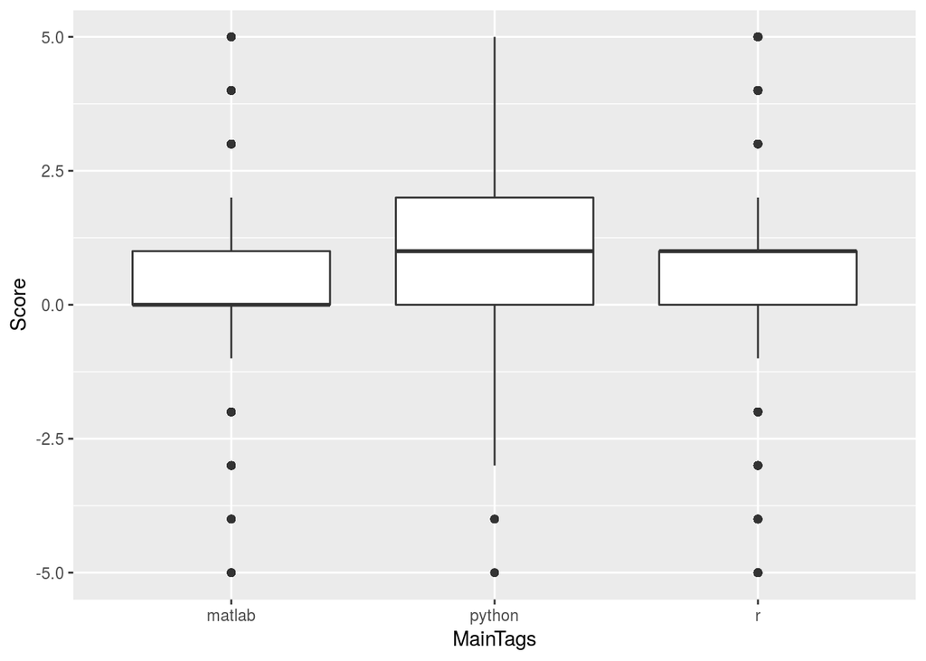

> Now we use a box plot to examine the distribution of scores per main tag. We notice how the scores are more dense in different quantiles for each of the maint tags.

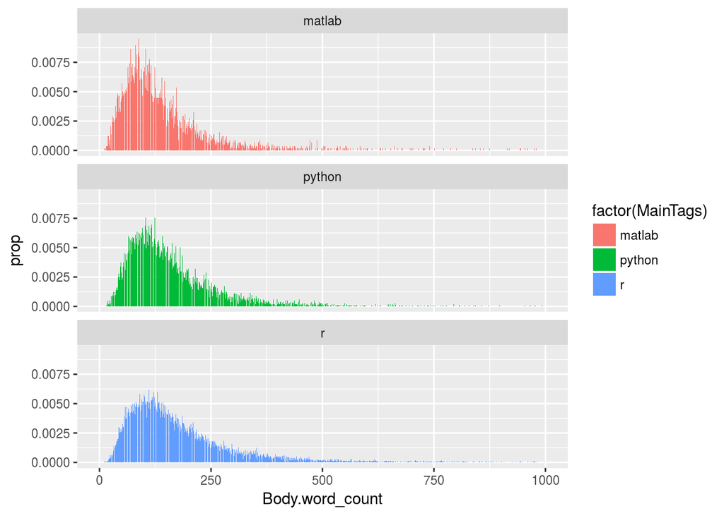

> Now we plot the proportion of word counts in the body of each post per main tag. We can quickly see ‘matlab’ posts have word counts more likely to be found on the lower end of the scale, while ‘r’ posts are more distributed.

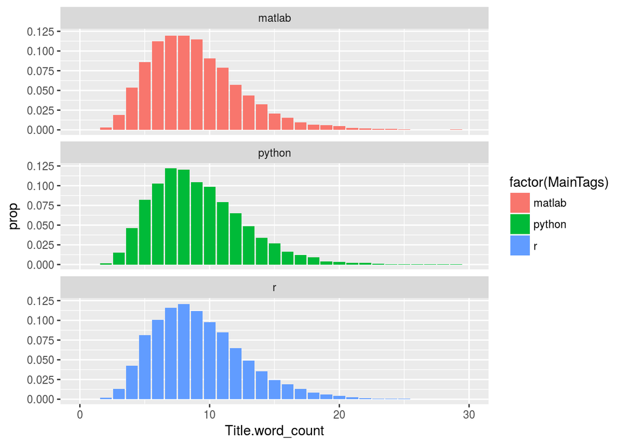

> Similar to the above plot, we now look at the proportion of word counts in the title of each post per main tag. Here, we see the posts have much more similar distributions.

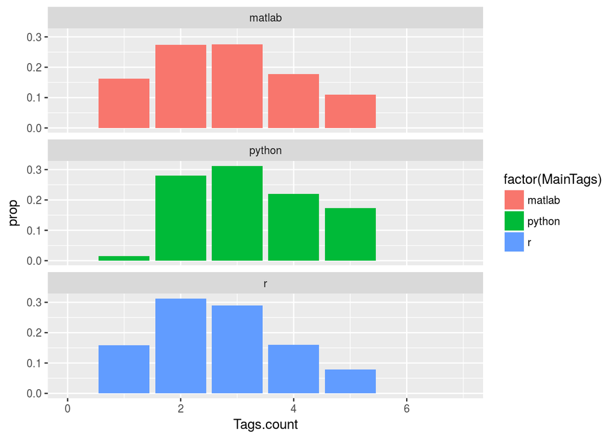

> And finally we look at the number of tags per post per main tag. We notice immedietly that ‘python’ has very little posts with only one tag, but this is most likely a result of the fact that the ‘python’ subset of data was found by looking at posts with ‘pandas’ as a tag. These posts will most likely, at a minimum, include both ‘pandas’ and ‘python’ as tags, hence the descrepency.

> Otherwise, we note the the three distributions are similar, with ‘r’ most likely to have two tags, ‘python’ most likely to have three, and ‘matlab’ to be about the same.

> We also notice that it is more likely to find four or five tags in a ‘python’ post versus the other two, and ‘r’ posts with five posts are not common relative to the other two main tags.

# Bivariate Analysis

The most prominent pattern found in these relationships is how the score of posts vary relative to each of the main tags the post belongs to. We see that the proportion of posts with a score of ‘0’ is much higher for ‘matlab’ than it is for ‘python’ and ‘r’ (with almost half of all ‘matlab’ posts having a score of ‘0’ and only about a quater of ‘python’ posts having a score of ‘0’, with ‘r’ in between).

We then see, as we consider higher scores, that ‘python’ posts are more likely to be scored higher relative to the other two and ‘matlab’ being scored lowered than the other two.

This may have to do with the underlying user base for each language. It may be that there are simply more Python users active on StackExchange than the are R or Matlab users, causing the liklihood of someone raising the score to be higher.

It’s also worth noting that ‘python’ posts are significantly less likely to have negative scores relative to the other tags. This is interesting in regards to the above theory, because different user counts don’t necessarily explain why ‘python’ posts recieve proportionally less negative scores than the other tags.

The word count in the body of each post per main tag is interesting as well. It would seem less words are required to convey a question for a ‘matlab’ post than for the other two tags.

# Multivariate Plots Section

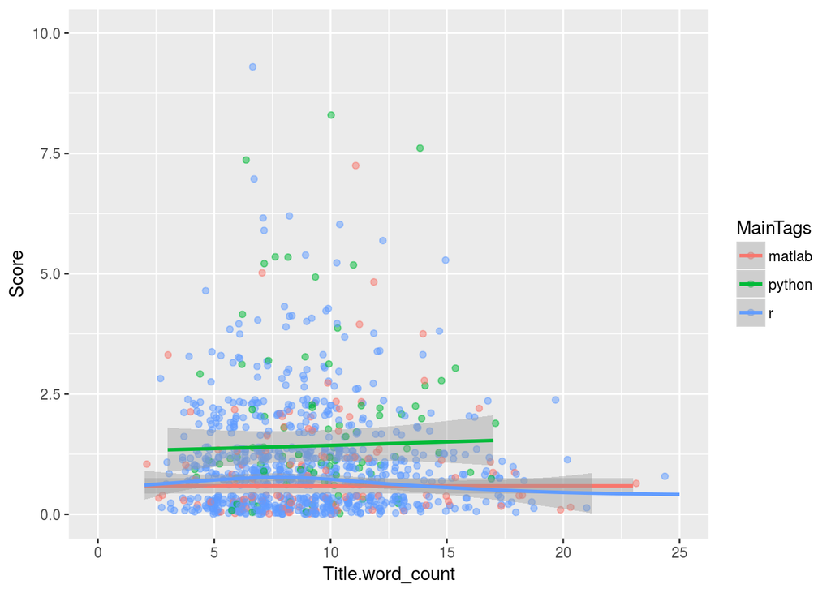

> In the preceding plot, we compare the amount of words in the title of a post with the score of the post, and color each point to correspond with the post’s main tag. We find no descernable pattern (i.e., there doesn’t seem to be a significant relationship between word count and scores).

```
## [1] 0.01264337
```

> We confirm by noting that the correlation coefficient is 0.01264337, which is very low.

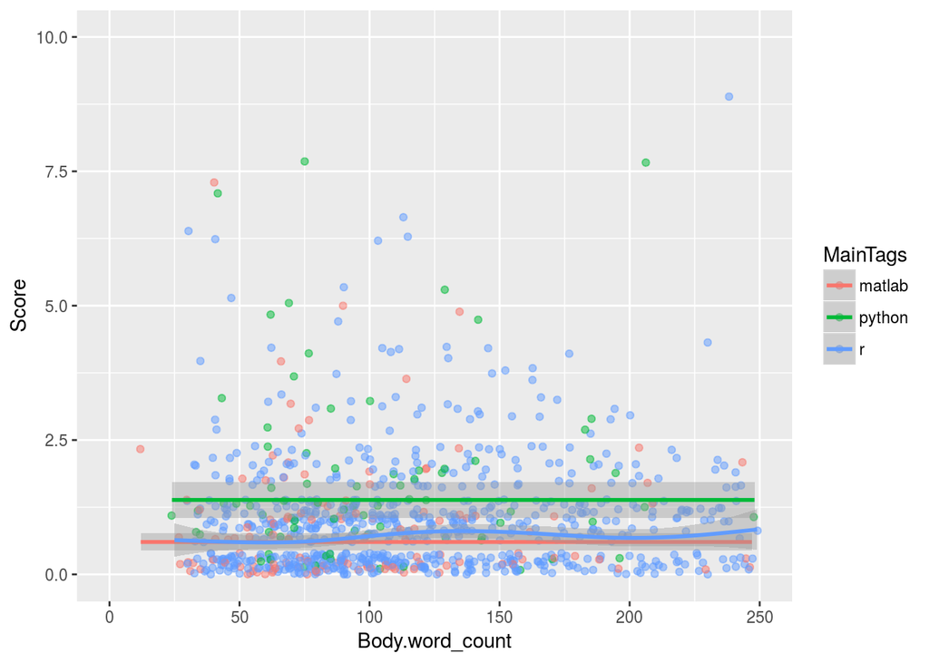

> Next, we plot something similar to above, but instead of considering the word count of the title of the post, we look at the word count of the body of the post. Again, we don’t see a strong correlation.

```
## [1] 0.06576517
```

> We confirm by noting that the correlation coefficient is 0.06576517, which is very low.

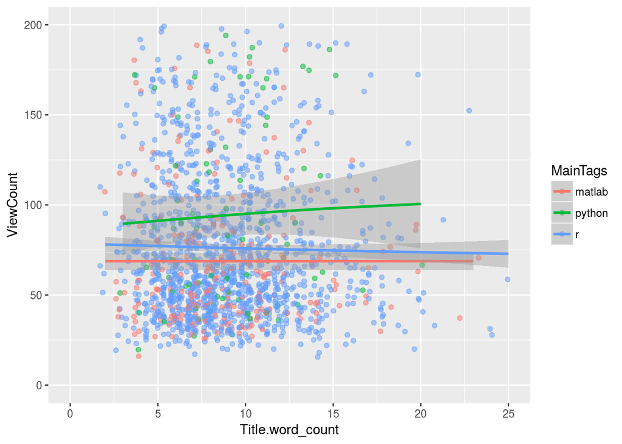

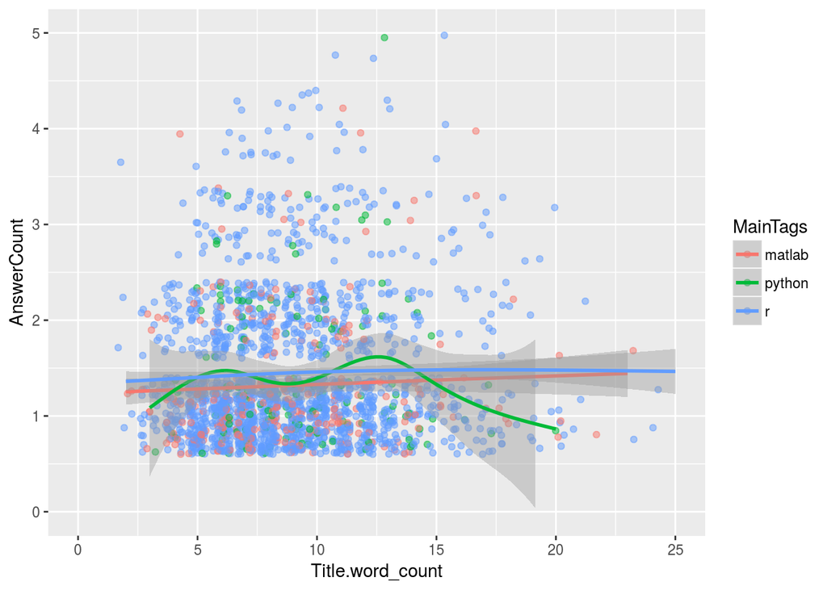

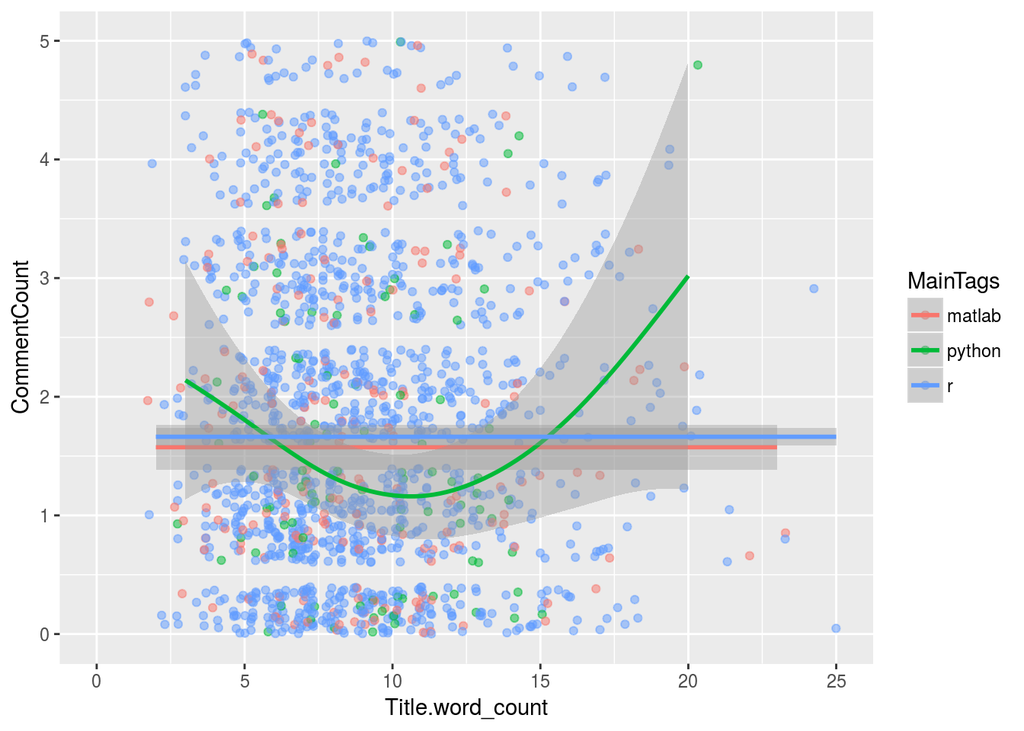

> In similar fashion, we examine the relationship between the word count of the title with the view count, answer count, and comment count, respectively. And, similar to before, we don’t notice any strong correlation.

```
## [1] -0.007562135
```

```
## [1] 0.04494172
```

```
## [1] 0.01306591
```